# Experiment 3 Timepoint 2 Analysis

Josh White

03/01/2022

# Introductory Steps

## Load Packages and set seed for reproducibility

```r
library(tidyverse)
library(here)

# Visualisation
library(ggsci)
library(ggrepel)
library(moderndive) # for geom_parallel_slopes_function because there is no way to do this in

# Modeling
library(lme4)
library(ordinal) # for clmm function
library(brms) # for Bayesian analyses

# Tables
library(flextable)
library(ftExtra)

theme_set(theme_classic())

set.seed(3838)
```

## Import Data

```r
db <- read_csv(
  here::here("experiment3", "timepoint2", "data", "exp3b-data.csv"),
  na = c("", "NA", "na")
  )

db_wid <- read_csv(
  here::here("experiment3", "timepoint2", "data", "3b_s-to-w.csv"),
  na = c("", "NA", "na")
  )

db <- db %>%
  left_join(db_wid)

#WRANGLE 3B

#make factors
db <- db %>%
  mutate(
    gender = factor(gender),
    income = factor(income, levels = c("<20k", "20to40k", "40to60K", "60to80k", "80to100k", ">100k")),
    vignette = factor(vignette, levels = c("G1", "G2", "G5", "G9", "G11",
                                           "L1", "L2", "L5", "L10", "L11")),
    education = as.numeric(education)
  )


# get ambiguity aversion and direction
db <- db %>%
  mutate(
    AA = case_when(
      resp_order == "A" ~ -(response - 4),
      resp_order == "B" ~ response - 4,
    ),
    direction = case_when(
      grepl("G", vignette) ~ "G",
      grepl("L", vignette) ~ "L"
    )
  )

#get whether passed attn_check or not
db <- db %>%
  mutate(
    attn_pass = dummyVignetteAnswer > 4
  )

# get basic descriptives before exclusion
demo_d <- db %>%
  distinct(subject, gender, age, education, income, attn_pass)

demo_d %>%  skimr::skim()
```

Data summary

| Name | Piped data |
| --- | --- |
| Number of rows | 247 |
| Number of columns | 6 |
| _______________________ |  |
| Column type frequency: |  |
| character | 1 |
| factor | 2 |
| logical | 1 |
| numeric | 2 |
| ________________________ |  |
| Group variables | None |

**Variable type: character**

| skim_variable | n_missing | complete_rate | min | max | empty | n_unique | whitespace |
| --- | --- | --- | --- | --- | --- | --- | --- |
| subject | 0 | 1 | 11 | 11 | 0 | 247 | 0 |

**Variable type: factor**

| skim_variable | n_missing | complete_rate | ordered | n_unique | top_counts |
| --- | --- | --- | --- | --- | --- |
| gender | 0 | 1.00 | FALSE | 3 | man: 144, wom: 102, oth: 1 |
| income | 4 | 0.98 | FALSE | 6 | 20t: 61, 40t: 52, 60t: 49, <20: 32 |

**Variable type: logical**

| skim_variable | n_missing | complete_rate | mean | count |
| --- | --- | --- | --- | --- |
| attn_pass | 0 | 1 | 0.96 | TRU: 237, FAL: 10 |

**Variable type: numeric**

| skim_variable | n_missing | complete_rate | mean | sd | p0 | p25 | p50 | p75 | p100 | hist |
| --- | --- | --- | --- | --- | --- | --- | --- | --- | --- | --- |
| age | 0 | 1.00 | 41.73 | 11.92 | 21 | 32 | 40 | 50 | 78 | ▆▇▆▃▁ |
| education | 8 | 0.97 | 15.28 | 2.57 | 2 | 14 | 16 | 16 | 22 | ▁▁▅▇▁ |

```r
demo_d %>%
  count(gender) %>%
  arrange(desc(n)) %>%
  flextable::flextable()
```

| gender | n |
| --- | --- |
| man | 144 |
| woman | 102 |
| other | 1 |

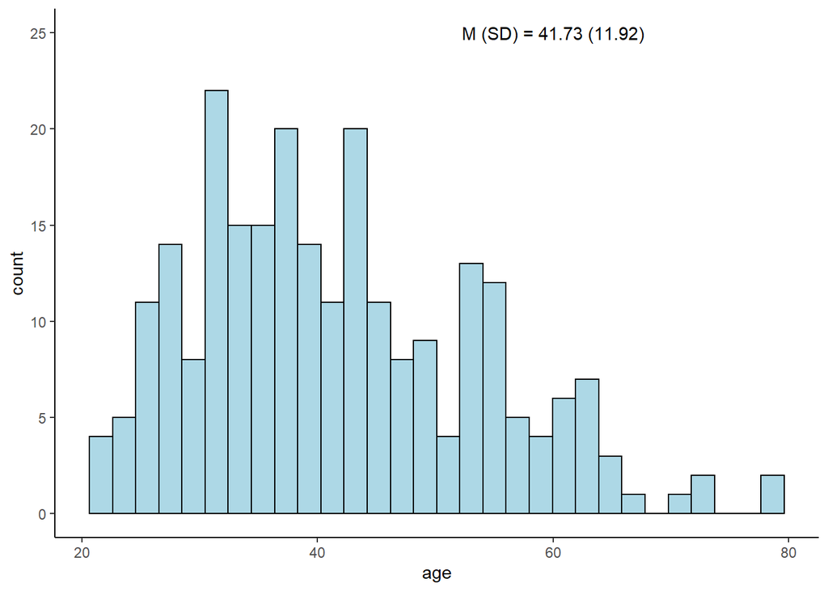

```r
demo_d %>%
  ggplot(aes(x = age)) +
  geom_histogram(fill = "light blue", col = "black") +
  annotate(geom = "text", x = 60, y = 25,
            label = paste0("M (SD) = ", round(mean(demo_d$age), 2), " (", round(sd(demo_d$age), 2), ")")
  )
```

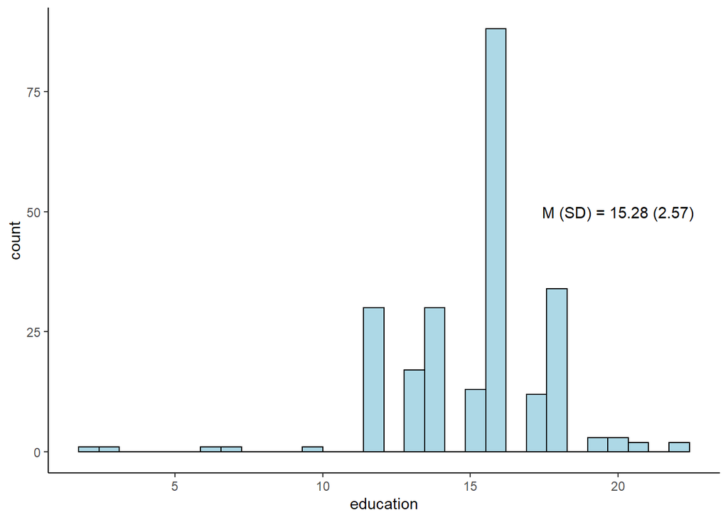

```r
demo_d %>%
  ggplot(aes(x = education)) +
  geom_histogram(fill = "light blue", col = "black") +
  annotate(geom = "text", x = 20, y = 50,
            label = paste0("M (SD) = ", round(mean(demo_d$education, na.rm = TRUE), 2),
                           " (", round(sd(demo_d$education, na.rm = TRUE), 2), ")")
  )
```

```r
demo_d %>%
  count(income) %>%
  arrange(desc(n)) %>%
  flextable::flextable()
```

| income | n |
| --- | --- |
| 20to40k | 61 |
| 40to60K | 52 |
| 60to80k | 49 |
| <20k | 32 |
| 80to100k | 25 |
| >100k | 24 |
|  | 4 |

## exclude participants

```r
#check whether observations fail instruction checks
demo_d %>%
  count(attn_pass) %>%
  flextable::flextable()
```

| attn_pass | n |
| --- | --- |
| FALSE | 10 |
| TRUE | 237 |

```r
d_pass <- db[db$attn_pass,]
```

## Plot Descriptives

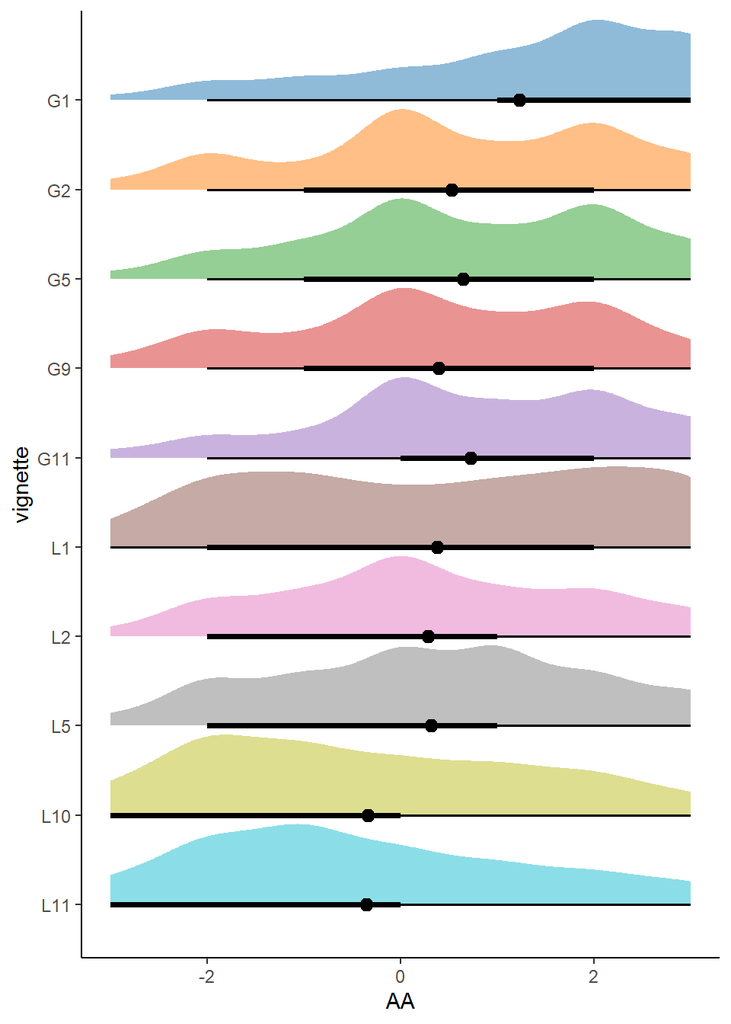

```r
library(ggdist)

# using ggdists
d_pass %>%
  ggplot(aes(x = AA, y = fct_rev(vignette), fill = vignette)) +
  stat_halfeye(point_interval = "mean_hdci",
               .width = c(.66, .95),
               slab_alpha = 0.5,
               normalize = "groups",
               show.legend = FALSE) +
  ggsci::scale_fill_d3() +
  labs(y = "vignette")
```

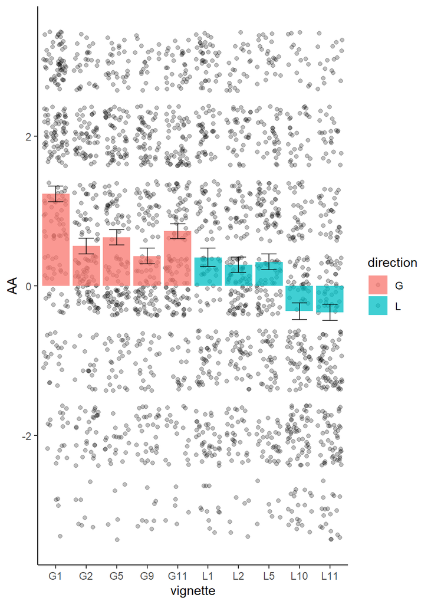

```r
# scatter and means
d_pass %>%
  ggplot(aes(x = vignette, y = AA, fill = direction)) +
  geom_jitter(alpha = 0.25) +
  stat_summary(geom = "bar", fun = mean, alpha = 0.75) +
  stat_summary(geom = "errorbar", fun.data = mean_se, alpha = 0.75, width = 0.5)
```

## Order effects (Trial number)

There is evidence of order effects as the model including trial order has superior fit. In both Bayesian and Frequentist models the model including an effect for `trialn` had a lower IC than the null model. Participants were less likely to choose a response option of higher ambiguity aversion as the trial number increased. For each trial the odds are multiplied by 0.96 (`exp(-0.04`), and the odds of choosing a higher ambiguity aversion option decrease by 30% compared to the the first trial (`exp(-0.04)^9`).

```r
m0 <- clmm(ordered(AA) ~ 1 + (1|subject) + (1|vignette), d_pass)
m_order <- clmm(ordered(AA) ~ 1 + trialn + (1|subject) + (1|vignette), d_pass)

AIC(m0)
```

```
## [1] 8190.336
```

```r
AIC(m_order)
```

```
## [1] 8180.754
```

```r
summary(m0)
```

```
## Cumulative Link Mixed Model fitted with the Laplace approximation
##
## formula: ordered(AA) ~ 1 + (1 | subject) + (1 | vignette)
## data:    d_pass
##
##  link  threshold nobs logLik   AIC     niter     max.grad cond.H
##  logit flexible  2370 -4087.17 8190.34 574(4300) 1.13e-02 3.4e+02
##
## Random effects:
##  Groups   Name        Variance Std.Dev.
##  subject  (Intercept) 2.0662   1.4374
##  vignette (Intercept) 0.3152   0.5615
## Number of groups:  subject 237,  vignette 10
##
## No Coefficients
##
## Threshold coefficients:
##       Estimate Std. Error z value
## -3|-2 -4.07708    0.23489 -17.357
## -2|-1 -2.14433    0.21139 -10.144
## -1|0  -1.18250    0.20792  -5.687
## 0|1    0.03685    0.20660   0.178
## 1|2    0.97545    0.20755   4.700
## 2|3    2.67491    0.21656  12.352
```

```r
summary(m_order)
```

```
## Cumulative Link Mixed Model fitted with the Laplace approximation
##
## formula: ordered(AA) ~ 1 + trialn + (1 | subject) + (1 | vignette)
## data:    d_pass
##
##  link  threshold nobs logLik   AIC     niter     max.grad cond.H
##  logit flexible  2370 -4081.38 8180.75 766(6430) 8.84e-04 1.9e+03
##
## Random effects:
##  Groups   Name        Variance Std.Dev.
##  subject  (Intercept) 2.0807   1.4425
##  vignette (Intercept) 0.3188   0.5646
## Number of groups:  subject 237,  vignette 10
##
## Coefficients:
##        Estimate Std. Error z value Pr(>|z|)
## trialn -0.04376    0.01287    -3.4 0.000673 ***
## ---
## Signif. codes:  0 '***' 0.001 '**' 0.01 '*' 0.05 '.' 0.1 ' ' 1
##
## Threshold coefficients:
##       Estimate Std. Error z value
## -3|-2  -4.3311     0.2478 -17.480
## -2|-1  -2.3905     0.2246 -10.642
## -1|0   -1.4218     0.2206  -6.445
## 0|1    -0.1974     0.2187  -0.903
## 1|2     0.7416     0.2195   3.379
## 2|3     2.4425     0.2277  10.725
```

```r
#bayes
m0_bayes <- brm(ordered(AA) ~ 1 + (1|subject) + (1|vignette),
                family = cumulative(link = "logit"),
                data = d_pass,
                cores = 4,
                refresh = 0, open_progress = FALSE)

m_order_bayes <- brm(ordered(AA) ~ 1 + trialn + (1|subject) + (1|vignette),
                     family = cumulative(link = "logit"),
                     data = d_pass,
                     cores = 4,
                     refresh = 0, open_progress = FALSE)

#MODELS
m0_bayes %>%  summary()
```

```
##  Family: cumulative
##   Links: mu = logit; disc = identity
## Formula: ordered(AA) ~ 1 + (1 | subject) + (1 | vignette)
##    Data: d_pass (Number of observations: 2370)
## Samples: 4 chains, each with iter = 2000; warmup = 1000; thin = 1;
##          total post-warmup samples = 4000
##
## Group-Level Effects:
## ~subject (Number of levels: 237)
##               Estimate Est.Error l-95% CI u-95% CI Rhat Bulk_ESS Tail_ESS
## sd(Intercept)     1.45      0.09     1.28     1.63 1.00     1140     2215
##
## ~vignette (Number of levels: 10)
##               Estimate Est.Error l-95% CI u-95% CI Rhat Bulk_ESS Tail_ESS
## sd(Intercept)     0.68      0.20     0.41     1.13 1.00      945     1846
##
## Population-Level Effects:
##              Estimate Est.Error l-95% CI u-95% CI Rhat Bulk_ESS Tail_ESS
## Intercept[1]    -4.08      0.27    -4.63    -3.56 1.01      806     1409
## Intercept[2]    -2.15      0.25    -2.66    -1.65 1.01      699     1191
## Intercept[3]    -1.18      0.25    -1.69    -0.70 1.01      675     1236
## Intercept[4]     0.04      0.25    -0.47     0.52 1.01      663     1158
## Intercept[5]     0.98      0.25     0.47     1.46 1.01      650     1211
## Intercept[6]     2.68      0.25     2.18     3.18 1.01      753     1240
##
## Family Specific Parameters:
##      Estimate Est.Error l-95% CI u-95% CI Rhat Bulk_ESS Tail_ESS
## disc     1.00      0.00     1.00     1.00 1.00     4000     4000
##
## Samples were drawn using sampling(NUTS). For each parameter, Bulk_ESS
## and Tail_ESS are effective sample size measures, and Rhat is the potential
## scale reduction factor on split chains (at convergence, Rhat = 1).
```

```r
m_order_bayes %>%  summary()
```

```
##  Family: cumulative
##   Links: mu = logit; disc = identity
## Formula: ordered(AA) ~ 1 + trialn + (1 | subject) + (1 | vignette)
##    Data: d_pass (Number of observations: 2370)
## Samples: 4 chains, each with iter = 2000; warmup = 1000; thin = 1;
##          total post-warmup samples = 4000
##
## Group-Level Effects:
## ~subject (Number of levels: 237)
##               Estimate Est.Error l-95% CI u-95% CI Rhat Bulk_ESS Tail_ESS
## sd(Intercept)     1.46      0.09     1.29     1.65 1.00     1028     1998
##
## ~vignette (Number of levels: 10)
##               Estimate Est.Error l-95% CI u-95% CI Rhat Bulk_ESS Tail_ESS
## sd(Intercept)     0.69      0.20     0.42     1.20 1.00     1224     1717
##
## Population-Level Effects:
##              Estimate Est.Error l-95% CI u-95% CI Rhat Bulk_ESS Tail_ESS
## Intercept[1]    -4.30      0.28    -4.83    -3.74 1.00      824     1380
## Intercept[2]    -2.35      0.26    -2.85    -1.83 1.00      757     1197
## Intercept[3]    -1.38      0.25    -1.88    -0.88 1.00      748     1148
## Intercept[4]    -0.16      0.25    -0.65     0.34 1.00      736     1126
## Intercept[5]     0.78      0.25     0.30     1.29 1.00      733     1164
## Intercept[6]     2.49      0.26     1.98     3.01 1.00      801     1419
## trialn          -0.04      0.01    -0.07    -0.02 1.00     5149     2888
##
## Family Specific Parameters:
##      Estimate Est.Error l-95% CI u-95% CI Rhat Bulk_ESS Tail_ESS
## disc     1.00      0.00     1.00     1.00 1.00     4000     4000
##
## Samples were drawn using sampling(NUTS). For each parameter, Bulk_ESS
## and Tail_ESS are effective sample size measures, and Rhat is the potential
## scale reduction factor on split chains (at convergence, Rhat = 1).
```

```r
##LOO COMPARE
loo(m0_bayes)
```

```
##
## Computed from 4000 by 2370 log-likelihood matrix
##
##          Estimate   SE
## elpd_loo  -3961.1 38.8
## p_loo       232.8  5.6
## looic      7922.2 77.5
## ------
## Monte Carlo SE of elpd_loo is 0.2.
##
## All Pareto k estimates are good (k < 0.5).
## See help('pareto-k-diagnostic') for details.
```

```r
loo(m_order_bayes)
```

```
##
## Computed from 4000 by 2370 log-likelihood matrix
##
##          Estimate   SE
## elpd_loo  -3953.5 38.8
## p_loo       231.7  5.6
## looic      7907.0 77.7
## ------
## Monte Carlo SE of elpd_loo is 0.3.
##
## All Pareto k estimates are good (k < 0.5).
## See help('pareto-k-diagnostic') for details.
```

### Plot order effects

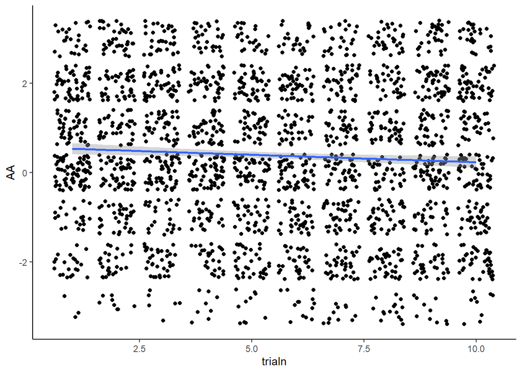

```r
d_pass %>%
  ggplot(aes(x = trialn, y = AA)) +
  geom_jitter() +
  geom_smooth(method = "lm")
```

### Distribution of vignettes at each trial

Our randomisation constraint of only accepting trial orders in which the pair vignettes were at least three places apart, selected a distribution in which the non-pairs vignettes were more likely in the middle of the trialorder, while the pairs vignettes were more likely at the end. This could explain (a very small part of) some of the differences in Ambiguity Aversion between vignettes. However, such a difference is not likely to cause issues, as our analysis is within-participants.

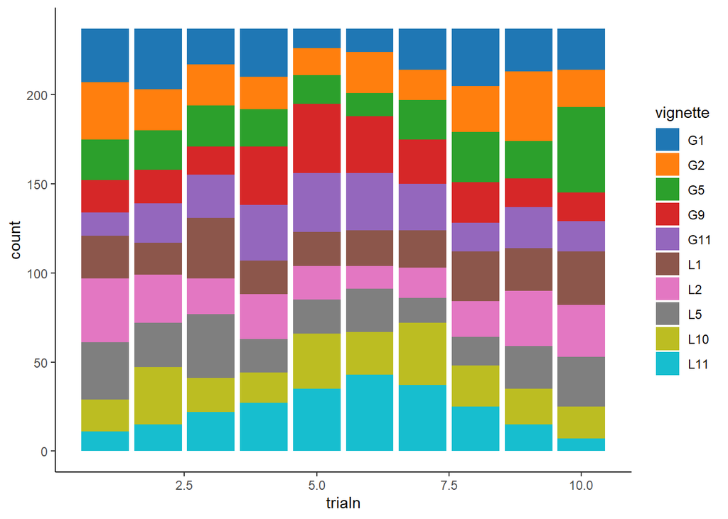

```r
d_pass %>%
  ggplot(aes(x = trialn, fill = vignette)) +
  geom_bar() +
  ggsci::scale_fill_d3()
```

However, even within each vignette, the order effect above is pretty consistent – all vignettes had a similar decreasing pattern to differing degrees (except G11 with v slight rise, and L2 and L5 which were pretty much flat)

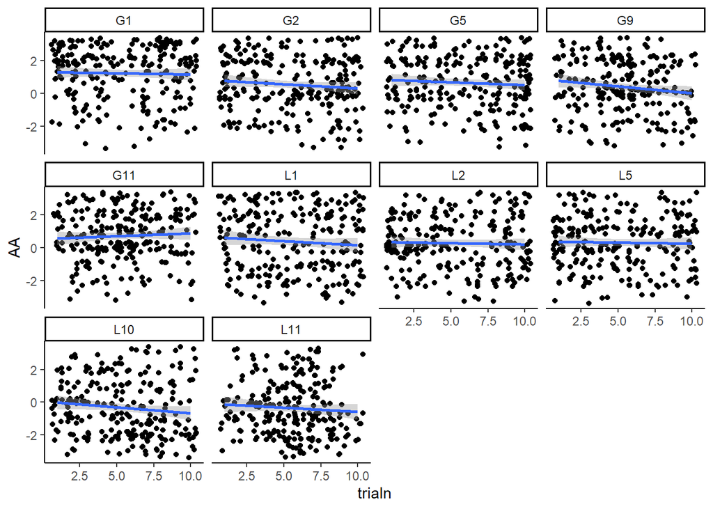

```r
d_pass %>%
  ggplot(aes(x = trialn, y = AA)) +
  geom_jitter() +
  geom_smooth(method = "lm") +
  facet_wrap(~vignette)
```

However, the pattern is not obvious at the individual level (which is quite noisy)

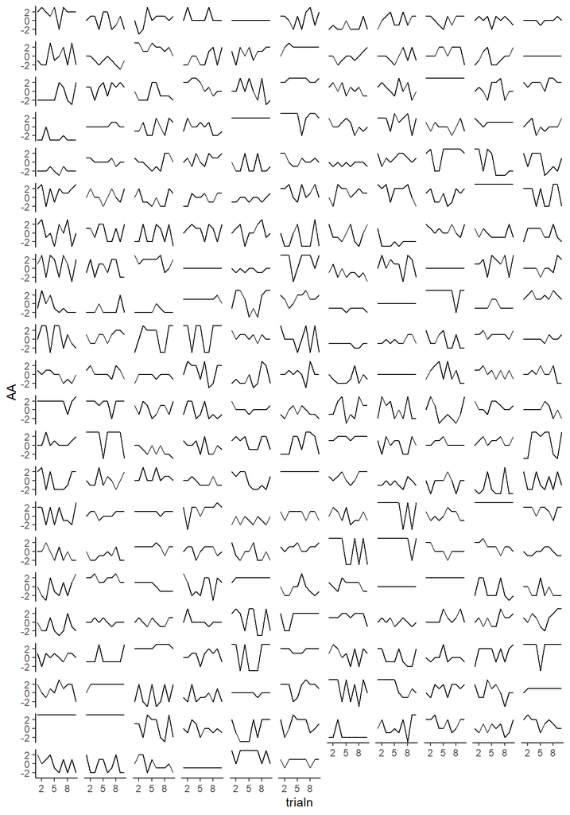

```r
#pattern not obvious at the individual level
d_pass %>%
  ggplot(aes(x = trialn, y = AA)) +
  geom_line() +
  facet_wrap(~subject, ncol = 11) +
  scale_x_continuous(breaks = c(2, 5, 8)) +
  theme(
    strip.background = element_blank(),
    strip.text.x = element_blank(),
    #axis.text.x = element_text(angle = 45, hjust = 1)
  )
```

## Relative order effects

Relative order has no effect on responses. AIC is lower for model without relative order parameter (LOOIC for Bayesian versions).

```r
d_pairs <- d_pass %>%
  filter(vignette %in% c("G1", "L1", "G2", "L2", "G5", "L5"))

d_pairs <- d_pairs %>%
  mutate(
    pair = case_when(
      vignette %in% c("G1", "L1") ~ "ones",
      vignette %in% c("G2", "L2") ~ "twos",
      vignette %in% c("G5", "L5") ~ "fives",
    )
)

#code rel_order variable, which is TRUE when gain version of pair occurs first and FALSE when Loss version is
d_pairs <- d_pairs %>%
  group_by(pair, subject) %>%
  mutate(
    rel_order_gfirst = trialn[grepl("G", vignette)] < trialn[grepl("L", vignette)]
  ) %>%
  ungroup()

## MODEL
#freq
m0_pairs <- clmm(ordered(AA) ~ 1 + (1|subject) + (1|vignette), d_pairs)
m_relorder <- clmm(ordered(AA) ~ 1 + rel_order_gfirst + (1|subject) + (1|vignette), d_pairs)

AIC(m0_pairs)
```

```
## [1] 4971.521
```

```r
AIC(m_relorder)
```

```
## [1] 4973.462
```

```r
summary(m0_pairs)
```

```
## Cumulative Link Mixed Model fitted with the Laplace approximation
##
## formula: ordered(AA) ~ 1 + (1 | subject) + (1 | vignette)
## data:    d_pairs
##
##  link  threshold nobs logLik   AIC     niter     max.grad cond.H
##  logit flexible  1422 -2477.76 4971.52 539(2665) 1.64e-03 2.0e+02
##
## Random effects:
##  Groups   Name        Variance Std.Dev.
##  subject  (Intercept) 1.9830   1.4082
##  vignette (Intercept) 0.1782   0.4221
## Number of groups:  subject 237,  vignette 6
##
## No Coefficients
##
## Threshold coefficients:
##       Estimate Std. Error z value
## -3|-2  -4.3581     0.2643 -16.489
## -2|-1  -2.3615     0.2159 -10.939
## -1|0   -1.4286     0.2088  -6.843
## 0|1    -0.1957     0.2052  -0.954
## 1|2     0.7454     0.2060   3.618
## 2|3     2.3886     0.2183  10.942
```

```r
summary(m_relorder)
```

```
## Cumulative Link Mixed Model fitted with the Laplace approximation
##
## formula: ordered(AA) ~ 1 + rel_order_gfirst + (1 | subject) + (1 | vignette)
## data:    d_pairs
##
##  link  threshold nobs logLik   AIC     niter     max.grad cond.H
##  logit flexible  1422 -2477.73 4973.46 689(3388) 8.05e-04 2.1e+02
##
## Random effects:
##  Groups   Name        Variance Std.Dev.
##  subject  (Intercept) 1.9818   1.4078
##  vignette (Intercept) 0.1776   0.4214
## Number of groups:  subject 237,  vignette 6
##
## Coefficients:
##                      Estimate Std. Error z value Pr(>|z|)
## rel_order_gfirstTRUE  0.02698    0.11060   0.244    0.807
##
## Threshold coefficients:
##       Estimate Std. Error z value
## -3|-2  -4.3451     0.2694 -16.131
## -2|-1  -2.3486     0.2220 -10.579
## -1|0   -1.4159     0.2150  -6.585
## 0|1    -0.1829     0.2115  -0.865
## 1|2     0.7583     0.2125   3.569
## 2|3     2.4015     0.2244  10.701
```

```r
#bayes
m0_pairs_bayes <- brm(ordered(AA) ~ 1 + (1|subject) + (1|vignette),
                data = d_pairs, family = cumulative(link = "logit"),
                #refresh = 0, open_progress = FALSE,
                cores = 4)

m_relorder_bayes <- brm(ordered(AA) ~ 1 + rel_order_gfirst + (1|subject) + (1|vignette),
               data = d_pairs, family = cumulative(link = "logit"),
                #refresh = 0, open_progress = FALSE,
               cores = 4)

#MODELS
m0_pairs_bayes %>%  summary()
```

```
##  Family: cumulative
##   Links: mu = logit; disc = identity
## Formula: ordered(AA) ~ 1 + (1 | subject) + (1 | vignette)
##    Data: d_pairs (Number of observations: 1422)
## Samples: 4 chains, each with iter = 2000; warmup = 1000; thin = 1;
##          total post-warmup samples = 4000
##
## Group-Level Effects:
## ~subject (Number of levels: 237)
##               Estimate Est.Error l-95% CI u-95% CI Rhat Bulk_ESS Tail_ESS
## sd(Intercept)     1.43      0.10     1.24     1.64 1.00     1155     2085
##
## ~vignette (Number of levels: 6)
##               Estimate Est.Error l-95% CI u-95% CI Rhat Bulk_ESS Tail_ESS
## sd(Intercept)     0.63      0.30     0.29     1.37 1.00     1055     1483
##
## Population-Level Effects:
##              Estimate Est.Error l-95% CI u-95% CI Rhat Bulk_ESS Tail_ESS
## Intercept[1]    -4.31      0.33    -4.96    -3.63 1.01      882     1429
## Intercept[2]    -2.31      0.29    -2.86    -1.70 1.01      842     1393
## Intercept[3]    -1.37      0.29    -1.92    -0.78 1.01      880     1285
## Intercept[4]    -0.14      0.29    -0.69     0.47 1.01      877     1321
## Intercept[5]     0.81      0.29     0.25     1.41 1.01      880     1293
## Intercept[6]     2.46      0.30     1.89     3.09 1.01      949     1385
##
## Family Specific Parameters:
##      Estimate Est.Error l-95% CI u-95% CI Rhat Bulk_ESS Tail_ESS
## disc     1.00      0.00     1.00     1.00 1.00     4000     4000
##
## Samples were drawn using sampling(NUTS). For each parameter, Bulk_ESS
## and Tail_ESS are effective sample size measures, and Rhat is the potential
## scale reduction factor on split chains (at convergence, Rhat = 1).
```

```r
m_relorder_bayes %>%  summary()
```

```
##  Family: cumulative
##   Links: mu = logit; disc = identity
## Formula: ordered(AA) ~ 1 + rel_order_gfirst + (1 | subject) + (1 | vignette)
##    Data: d_pairs (Number of observations: 1422)
## Samples: 4 chains, each with iter = 2000; warmup = 1000; thin = 1;
##          total post-warmup samples = 4000
##
## Group-Level Effects:
## ~subject (Number of levels: 237)
##               Estimate Est.Error l-95% CI u-95% CI Rhat Bulk_ESS Tail_ESS
## sd(Intercept)     1.43      0.10     1.24     1.65 1.00     1202     2310
##
## ~vignette (Number of levels: 6)
##               Estimate Est.Error l-95% CI u-95% CI Rhat Bulk_ESS Tail_ESS
## sd(Intercept)     0.62      0.27     0.30     1.37 1.00     1136     1574
##
## Population-Level Effects:
##                      Estimate Est.Error l-95% CI u-95% CI Rhat Bulk_ESS
## Intercept[1]            -4.33      0.34    -4.99    -3.63 1.00     1256
## Intercept[2]            -2.32      0.30    -2.89    -1.72 1.00     1149
## Intercept[3]            -1.39      0.29    -1.94    -0.79 1.00     1102
## Intercept[4]            -0.15      0.29    -0.70     0.46 1.00     1111
## Intercept[5]             0.79      0.29     0.24     1.41 1.00     1135
## Intercept[6]             2.44      0.30     1.88     3.06 1.00     1203
## rel_order_gfirstTRUE     0.03      0.11    -0.19     0.24 1.00     4174
##                      Tail_ESS
## Intercept[1]             1792
## Intercept[2]             1597
## Intercept[3]             1741
## Intercept[4]             1704
## Intercept[5]             1609
## Intercept[6]             1849
## rel_order_gfirstTRUE     3139
##
## Family Specific Parameters:
##      Estimate Est.Error l-95% CI u-95% CI Rhat Bulk_ESS Tail_ESS
## disc     1.00      0.00     1.00     1.00 1.00     4000     4000
##
## Samples were drawn using sampling(NUTS). For each parameter, Bulk_ESS
## and Tail_ESS are effective sample size measures, and Rhat is the potential
## scale reduction factor on split chains (at convergence, Rhat = 1).
```

```r
##LOO COMPARE
loo(m0_pairs_bayes)
```

```
##
## Computed from 4000 by 1422 log-likelihood matrix
##
##          Estimate   SE
## elpd_loo  -2400.6 29.2
## p_loo       205.1  6.1
## looic      4801.2 58.4
## ------
## Monte Carlo SE of elpd_loo is 0.3.
##
## All Pareto k estimates are good (k < 0.5).
## See help('pareto-k-diagnostic') for details.
```

```r
loo(m_relorder_bayes)
```

```
##
## Computed from 4000 by 1422 log-likelihood matrix
##
##          Estimate   SE
## elpd_loo  -2401.2 29.3
## p_loo       206.8  6.2
## looic      4802.5 58.6
## ------
## Monte Carlo SE of elpd_loo is 0.3.
##
## All Pareto k estimates are good (k < 0.5).
## See help('pareto-k-diagnostic') for details.
```